# Epidemiologia de la salud mental mundial

Datos de 1990 a 2017

# Introduccion

El presente informe resume los datos obtenidos en censos de salud mental de 196 paises en todo el mundo en un periodo de 28 años, desde 1990 a 2017.

Los datos fueron obtenidos de https://ourworldindata.org/

### Breve analisis de las dimensiones del dataset y de los datos faltantes

```
## [1] "Nro de columnas del df:  11"
## [1] "Nro de filas del df:  5488"
## [1] "Cantidad de valores faltantes en el df:  0"
```

### Paises participantes

|  | Entity |
| --- | --- |
| 1 | Afghanistan |
| 2 | Albania |
| 3 | Algeria |
| 4 | American Samoa |
| 5 | Andorra |
| 6 | Angola |
| 7 | Antigua and Barbuda |
| 8 | Argentina |
| 9 | Armenia |
| 10 | Australia |

[output cut: 186 more lines]

### Diagnosticos evaluados

```
## [1] "Schizophrenia"         "Bipolar.disorder"      "Eating.disorders"
## [4] "Anxiety.disorders"     "Drug.use.disorders"    "Depression"
## [7] "Alcohol.use.disorders"
```

### Prevalencia total por pais

La siguiente tabla ordena los paises por su prevalencia total de los trastornos mentales evaluados (columna “Prevalencia_Promedio”) en orden descendente. La columna “Prevalencia_Desvio_Estandar”, como su nombre lo indica, revela el desvio estandar correspondiente a ese pais, con el objetivo de observar la variabilidad de la prevalencia a lo largo de los años.

La mayoria de los paises parece tener un desvio estandar bajo, lo cual sugiere que la prevalencia no vario mucho durante las decadas. Curiosamente, EEUU, Iran y Brazil representan una excepcion. Esto podria deberse a grandes estresores que debieron afrontar los paises en años especificos, por ejemplo una guerra. Una gran variabilidad tambien podria hacernos sospechar de la validez y confiabilidad del metodo de recoleccion de datos. Sin embargo, al menos para los paises mas relevantes (aquellos al principio y final de la tabla), y a excpecion de los tres paises mencionados, el desvio estandar parece ser bajo.

|  | Entity | Prevalencia_Promedio | Prevalencia_Desvio_Estandar |
| --- | --- | --- | --- |
| 1 | Greenland | 18.7872511709333 | 0.170381282741084 |
| 2 | New Zealand | 18.7278575540897 | 0.15993955601584 |
| 3 | United States | 17.8830796368637 | 0.478393138019372 |
| 4 | Australia | 17.3774983718472 | 0.168165247325897 |
| 5 | Iran | 15.5925779238837 | 0.348021411577145 |
| 6 | Norway | 15.5235262087164 | 0.311757060592654 |
| 7 | France | 15.3759331798882 | 0.0838493933404026 |
| 8 | Chile | 15.3156475679738 | 0.156840042266159 |
| 9 | Germany | 14.961890215301 | 0.0974471024071811 |
| 10 | Brazil | 14.9441361760859 | 0.599337700244871 |

[output cut: 186 more lines]

### Comparación entre países

El gráfico a continuacion representa la diferencia en prevalencia total de trastornos mentales entre paises, seleccionando el top 5 paises de mayor prevalencia (primeros 5 paises del grafico) y el top 5 de menor prevalencia (ultimos 5 paises del grafico). Esto permite concluir que algunos paises tienen el doble de prevalencia de trastornos mentales.

Por ejemplo, nacer en Groenlandia implica el doble de chances de desarollar un trastorno mental que al nacer en Indonesia.

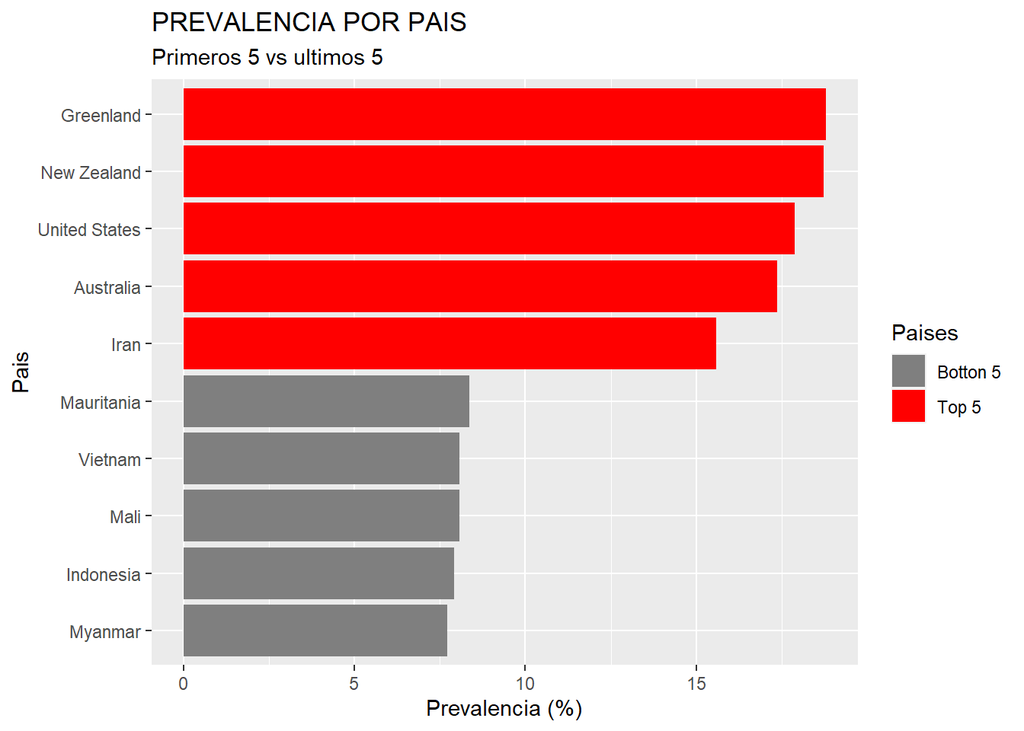

# Comparación entre años

Puede observarse como la prevalencia total en todo el mundo no cambio significativamente. De todas formas, puede observarse un aumento de un poco mas del 0.1% desde el comienzo de los ’90 hasta el 2017.

```
## Aumento de la prevalencia total mundial desde 1990 a 2017 :  0.121175 %
```

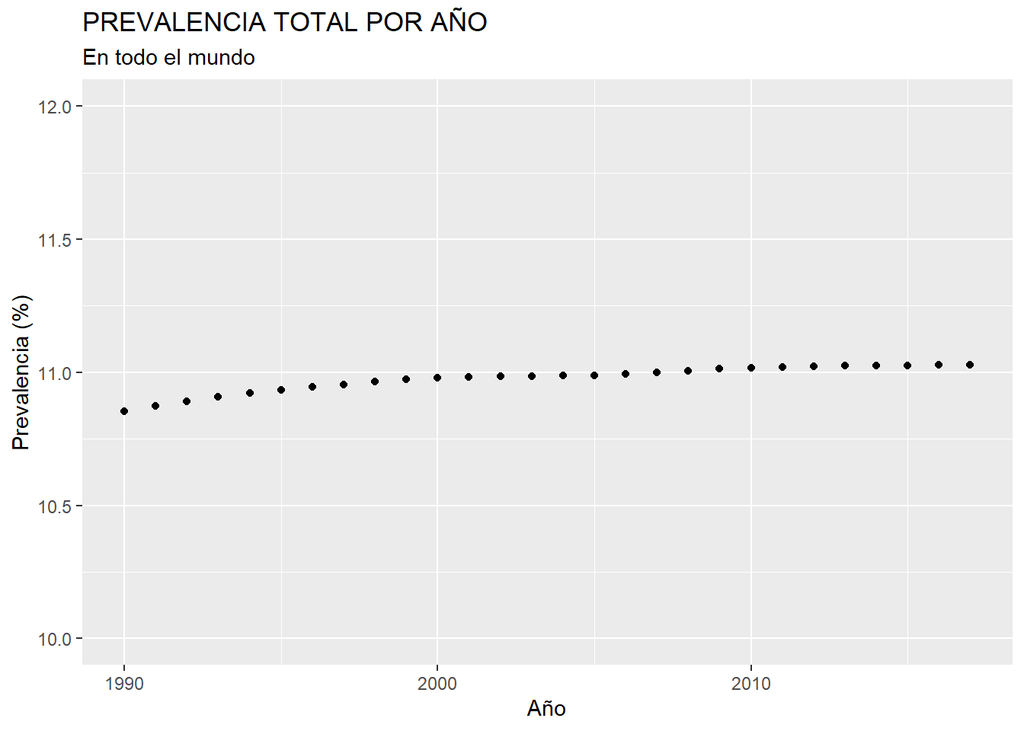

## Comparación entre trastornos

El siguiente grafico nos permite obtener un resumen visual de todas las enfermedades estudiadas (haciendo un promedio de todos los paises en todos los años). El eje x corresponde al desvio estandar, y el eje y a la prevalencia.

Para empezar, llama la atencion cierta correlacion entre ambas variables. Esto es, cuanto mayor su prevalencia, tambien mayor su variabilidad. Esto implica que dos paies (o el mismo pais en años distintos) pueden tener prevalencias muy distintas de trastornos de ansiedad, pero tendran una prevalencia bastante similar de esquizofrania.

Por otro lado, una comparacion interesante puede ser la del trastorno bipolar (TB) con los trastornos de la conducta alimenticia (TCA). Ambos tienen la misma variabilidad, pero el TB tiene una prevalencia mayor. Por el contrario, tiene la misma prevalencia que los trastornos por consumo de sustancias, pero el segundo tiene una variabilidad mucho mayor.

Finalmente, parece formarse un grupo concentrado de tres trastornos de baja prevalencia y baja variabilidad, muy similares entre si: esquizofrenia, TB y TCA.

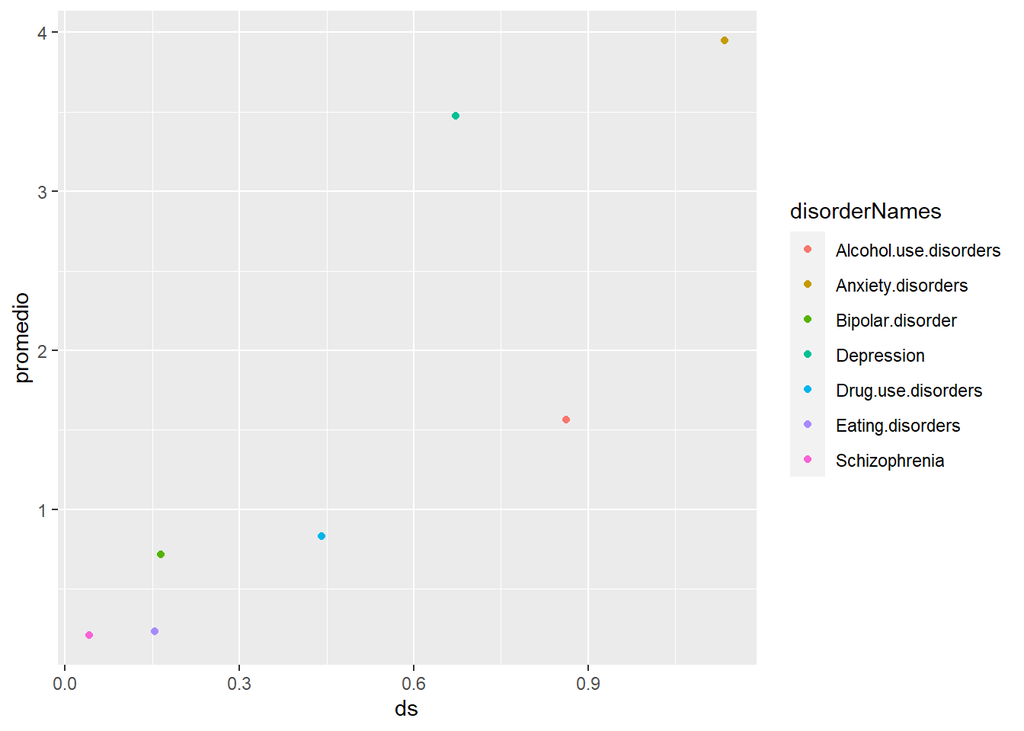

# Comparación entre años por tipo de enfermedad

Puede observarse como cada uno de los trastornos mantiene su prevalencia a lo largo de los años.

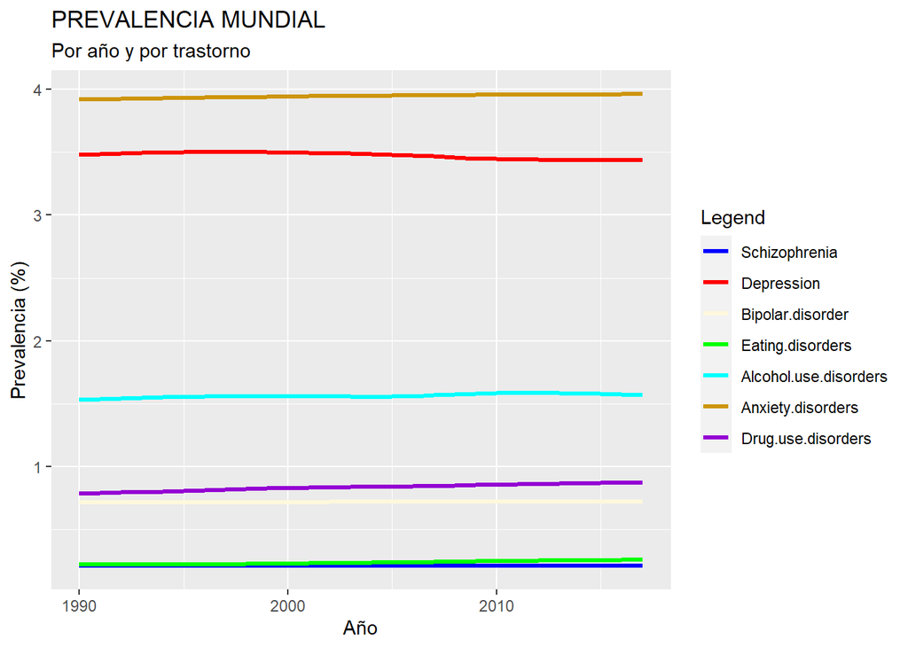

Sin embargo, puede existir un cambio real en la prevalencia tan pequeño que resulte inobservable en un grafico. Veamos el cambio en cada uno de los diagnosticos.

[output not shown]

# El caso del trastorno por consumo de sustancias.

Al graficarlo, observamos mejor como su prevalencia aumenta.

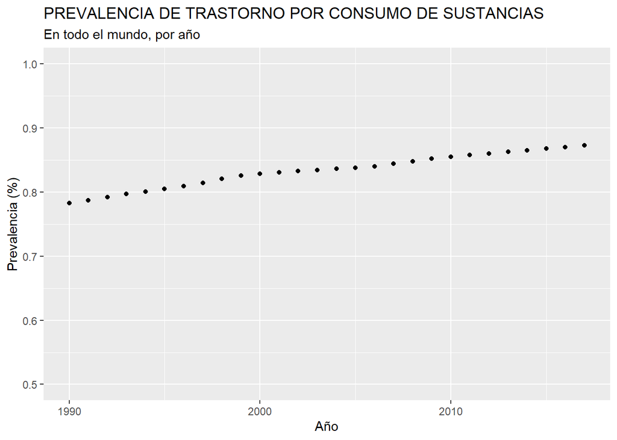

# El caso de la Argnentina.

| Year | “Argentina” | Prevalencia_Total |
| --- | --- | --- |
| 1990 | Argentina | 13.84725 |
| 1991 | Argentina | 13.97338 |
| 1992 | Argentina | 14.09058 |
| 1993 | Argentina | 14.18882 |
| 1994 | Argentina | 14.26308 |
| 1995 | Argentina | 14.30270 |
| 1996 | Argentina | 14.32318 |
| 1997 | Argentina | 14.33839 |
| 1998 | Argentina | 14.34949 |
| 1999 | Argentina | 14.36243 |
| 2000 | Argentina | 14.37154 |
| 2001 | Argentina | 14.38359 |
| 2002 | Argentina | 14.40076 |
| 2003 | Argentina | 14.41657 |
| 2004 | Argentina | 14.42843 |
| 2005 | Argentina | 14.42784 |
| 2006 | Argentina | 14.38354 |
| 2007 | Argentina | 14.29153 |
| 2008 | Argentina | 14.18467 |
| 2009 | Argentina | 14.09538 |
| 2010 | Argentina | 14.06066 |
| 2011 | Argentina | 14.06220 |
| 2012 | Argentina | 14.07050 |
| 2013 | Argentina | 14.08177 |
| 2014 | Argentina | 14.09754 |
| 2015 | Argentina | 14.11494 |
| 2016 | Argentina | 14.13601 |
| 2017 | Argentina | 14.15808 |

Tomando como referencia a nuetro vecino.

[output not shown]